# Principles of visualization exercises

Jon Chernus

# 1 Exploratory visualization

## Randomization

- If your birthday is on an odd-numbered day (1, 3, 5, … , 31), you are in Group A.
- If your birthday is on an even-numbered day (2, 4, 6, … , 30), you are in Group B.

## Exploration

Download `data1.csv`.

Spend ~5 minutes on the task below, depending on your group.

### Group A task

Investigate whether there is a correlation between `v3` and `v4`. Make two plots and write 3–5 sentences describing what you conclude.

### Group B task

Explore the dataset visually. Make three different plots and write 3–5 sentences describing anything unusual or structured you find.

```r
### Your code here
```

# 2. Data-ink ratio (and learning `ggplot` options)

What is the data-ink ratio like for this plot?

Copy the code for this plot and paste it into the blank chunk below. Read and tinker with the (copied and pasted) code to figure out which commands and parameters control which graphical elements. Improve the data-ink ratio as much as reasonably possible.

```r
library(tidyverse)
```

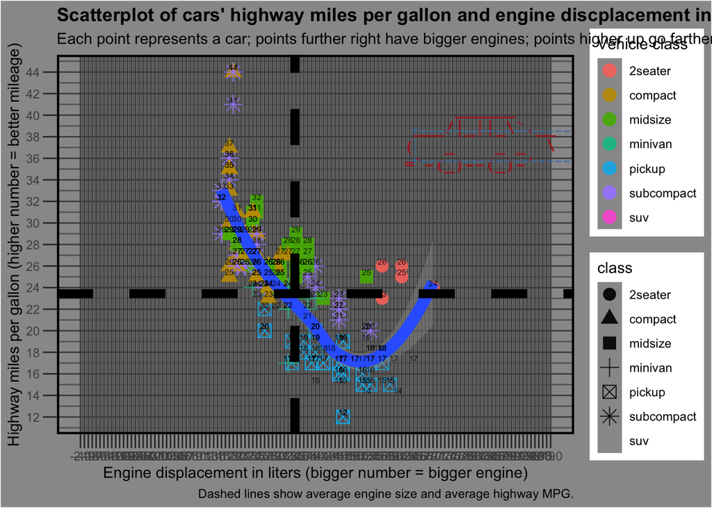

```r
p_bad <- ggplot(mpg, aes(displ, hwy)) +

  geom_point(
    aes(color = class, shape=class, fill=class),
    size = 4,
    alpha = 0.9
  ) +

  geom_smooth(
    method = "loess",
    se = TRUE,
    linewidth = 4
  ) +

  geom_vline(
    xintercept = mean(mpg$displ),
    linetype = "dashed",
    linewidth = 3
  ) +
  geom_hline(
    yintercept = mean(mpg$hwy),
    linetype = "dashed",
    linewidth = 3
  ) +

  geom_text(
    aes(label = hwy),
    size = 2,
    alpha = 0.8,
    vjust = -0.3
  ) +

  labs(
    title = "Scatterplot of cars' highway miles per gallon and engine discplacement in liters colored by vehicle class",
    subtitle = "Each point represents a car; points further right have bigger engines; points higher up go farther on one gallon",
    x = "Engine displacement in liters (bigger number = bigger engine)",
    y = "Highway miles per gallon (higher number = better mileage)",
    color = "Vehicle class",
    caption = "Dashed lines show average engine size and average highway MPG."
  ) +

  scale_x_continuous(
    limits = c(-2, 10),
    breaks = seq(-2, 10, by = 0.1),
    minor_breaks = seq(-2, 10, by = 0.05)
  ) +
  scale_y_continuous(
    breaks = seq(10, 50, by = 2),
    minor_breaks = seq(10, 50, by = 1)
  ) +

  # Heavy theme elements
  theme(
    panel.grid.major = element_line(color = "grey30", linewidth = 0.5),
    panel.grid.minor = element_line(color = "grey40", linewidth = 0.5),
    panel.border = element_rect(fill = NA, linewidth = 1.5),
    axis.ticks.length = unit(0.35, "cm"),
    plot.title = element_text(face = "bold"),
    panel.background = element_rect(fill = "grey60"),
    plot.background = element_rect(fill = "grey60")
  ) +

  annotate(
    "text",
    x = 6, y = 41, fontface="bold", size=4.2,
    label = paste(
      "      ______",
      "  ___/|_||_\\`.__",
      " (   _    _ _  \\",
      " =`-(_)--(_)-'  ",
      sep = "\n"
    ),
    family = "mono",
    size = 3.5,
    lineheight = 0.9,
    hjust = 0, vjust = 1,
    color = "firebrick",
    alpha = 0.9
  ) +
  annotate(
    "text",
    x = 6, y = 39,
    label = paste(
      "  +----------------------+",
      "  |                      |",
      "  +----------------------+",
      sep = "\n"
    ),
    family = "mono",
    size = 3.5,
    lineheight = 0.9,
    hjust = 0, vjust = 1,
    color = "steelblue",
    alpha = 0.9
  )
p_bad
```

```r
### Your code here
```

# 3. Spaghetti plot

Below we have a spaghetti plot: too many overlapping lines, one for each value of `feature`.

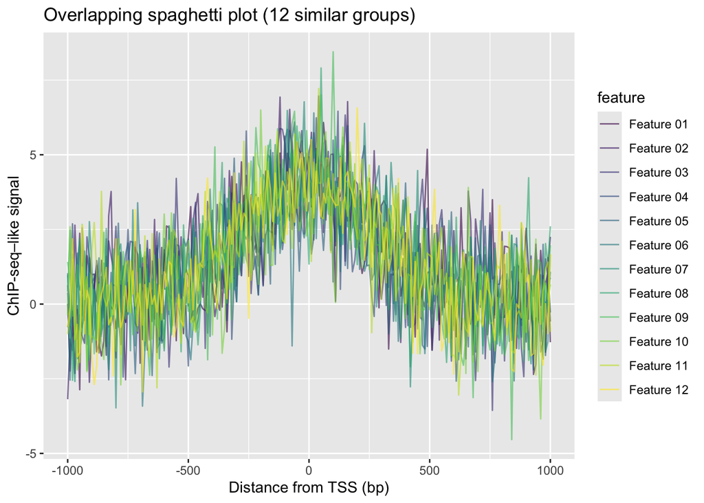

```r
library(dplyr)
library(ggplot2)

set.seed(2)

features <- paste0("Feature ", sprintf("%02d", 1:12))
positions <- seq(-1000, 1000, by = 10)

df <- expand.grid(
  feature = factor(features, levels = features, ordered = TRUE),
  pos   = positions
) %>%
  mutate(
    g = as.integer(feature),

    # Make groups VERY similar
    peak_height = 4 + rnorm(length(features), 0, 0.3)[g],  # small differences
    peak_sd     = 260 + rnorm(length(features), 0, 15)[g], # similar width

    # Shared structure + noise → overlap
    signal = peak_height * exp(-(pos^2) / (2 * peak_sd^2)) +
             rnorm(n(), sd = 1.3)
  )

ggplot(df, aes(x = pos, y = signal, color = feature)) +
  geom_line(alpha = 0.6) +
  labs(
    x = "Distance from TSS (bp)",
    y = "ChIP-seq–like signal",
    title = "Overlapping spaghetti plot (12 similar groups)"
  )
```

We could simply use `facet_wrap(~feature)` to produce separate plots. But suppose we’d like to be able to directly compare the curves by highlighting one feature in each facet while backgrounding the rest.

Unfortunately, it takes a bit of work to do that.

- First, we need to make a new version of the entire dataset, where every row is repeated once for each panel; we do this with the `crossing` function and make a grouping variable called `panel` (this is done for you in the code below). There is one group for each feature (i.e., each value of `feature`). This data frame, `df_bg`, will be used for the backgrounded lines.
- Second, for our foreground, where we highlight a single feature in each panel of the faceted graph, we also need a foreground data frame, `df_fg`, with a column called `panel`, which is just a copy of the `feature` column. (Also done for you.)
- Now you just need a a `ggplot` command where you include a `geom_line` based on `df_bg` (you need to include `group=feature`), another based on `df_fg`, and a `facet_wrap`.

Complete the code below:

```r
# df has columns: group, pos, signal
# group is a factor with your 20 levels
head(df)
```

```
##      feature   pos g peak_height  peak_sd       signal
## 1 Feature 01 -1000 1    3.730926 254.1096  0.008036928
## 2 Feature 02 -1000 2    4.055455 244.4050 -3.186279036
## 3 Feature 03 -1000 3    4.476354 286.7334  0.630635453
## 4 Feature 04 -1000 4    3.660887 225.3340 -0.775331994
## 5 Feature 05 -1000 5    3.975924 273.1791  1.034758237
## 6 Feature 06 -1000 6    4.039726 260.5371  0.379082454
```

```r
# Background data: replicate ALL lines into ALL panels
df_bg <- df %>%
  tidyr::crossing(panel = levels(df$feature))   # every row repeated for every facet
head(df_bg)
```

```
## # A tibble: 6 × 7
##   feature      pos     g peak_height peak_sd  signal panel
##   <ord>      <dbl> <int>       <dbl>   <dbl>   <dbl> <chr>
## 1 Feature 01 -1000     1        3.73    254. 0.00804 Feature 01
## 2 Feature 01 -1000     1        3.73    254. 0.00804 Feature 02
## 3 Feature 01 -1000     1        3.73    254. 0.00804 Feature 03
## 4 Feature 01 -1000     1        3.73    254. 0.00804 Feature 04
## 5 Feature 01 -1000     1        3.73    254. 0.00804 Feature 05
## 6 Feature 01 -1000     1        3.73    254. 0.00804 Feature 06
```

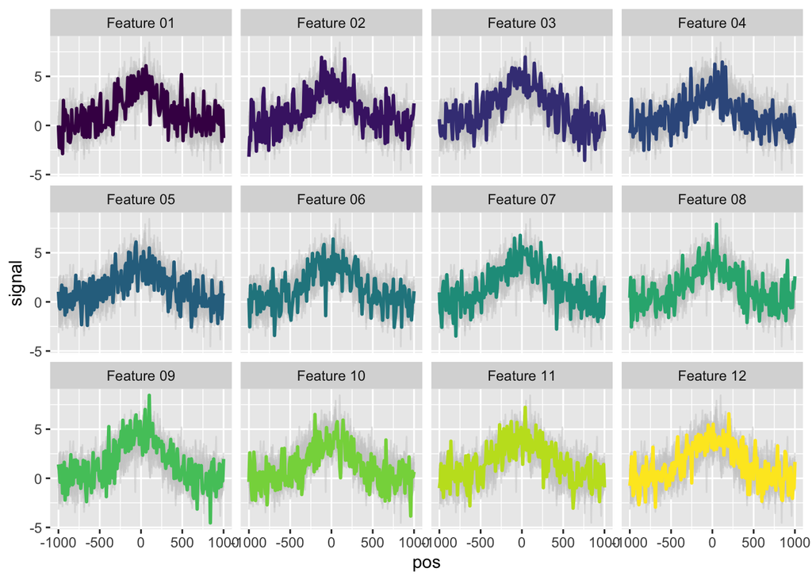

```r
# Foreground data: only the focal group's line in its own panel
df_fg <- df %>%
  mutate(panel = feature)

ggplot() +
  # background: all groups in every panel (gray)
  geom_line(
    data = df_bg,
    aes(x = pos, y = signal, group = feature),
    color = "grey80",
    alpha = 0.5
  ) +
  # foreground: highlight the panel's group (colored)
  geom_line(
    data = df_fg,
    aes(x = pos, y = signal, group = feature, color = feature),
    linewidth = 1
  ) +
  facet_wrap(~ panel) +
  guides(color = "none") +
  labs(x = "pos", y = "signal")
```

# 4. Color palettes

Here you’ll learn how to use the `RColorBrewer` package for built-in and custom palettes.

First, check out the built-in options:

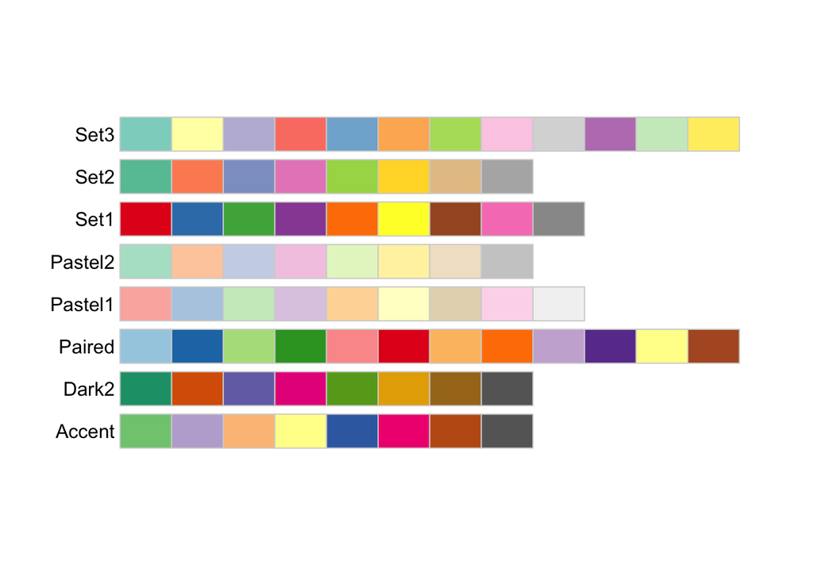

```r
library("RColorBrewer")
RColorBrewer::display.brewer.all(type = "qual")
```

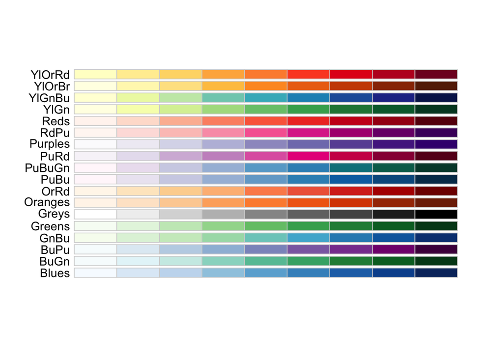

```r
RColorBrewer::display.brewer.all(type = "seq")
```

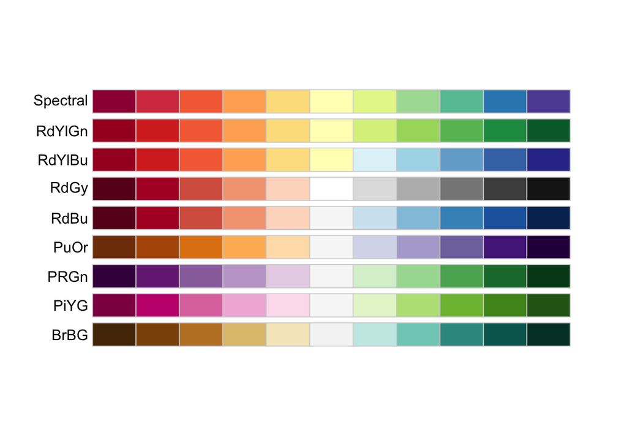

```r
RColorBrewer::display.brewer.all(type = "div")
```

## Colors for a few groups

In the barplot below, suppose we want to distinguish all 4 groups equally.

Modify the code as follows:

- Use `aes()` to map `group` to `color`
- Pick an appropriate palette from above and add `+ scale_color_brewer(palette="your palette choice here">)` to the plotting command
- Notice that that only outlines the bar; instead, use `fill` and `scale_fill_brewer`

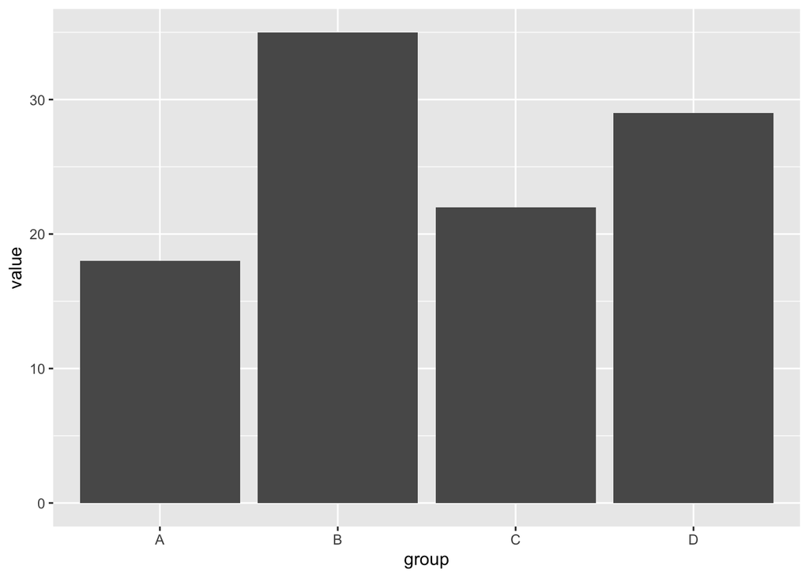

```r
data.frame(
  group = c("A", "B", "C", "D"),
  value = c(18, 35, 22, 29)
) %>% ggplot(aes(x = group, y = value)) +
  geom_col()
```

## Colors for ordered groups

In the barplot below, notice that the default color palette is not appropriate.

- What kind of palette would be appropriate? Use `scale_fill_brewer` as above to apply a good one.
- Now look at the legend. Can you see anything wrong? The colors are not correctly mapped to the categories.
- Use the `limits` option of `scale_fill_brewer` to begin fixing this by listing the categories in their natural order (note that another option would be to re-encode the ordinal variable a an ordered factor). The vector `af_bins` has been provided for you.

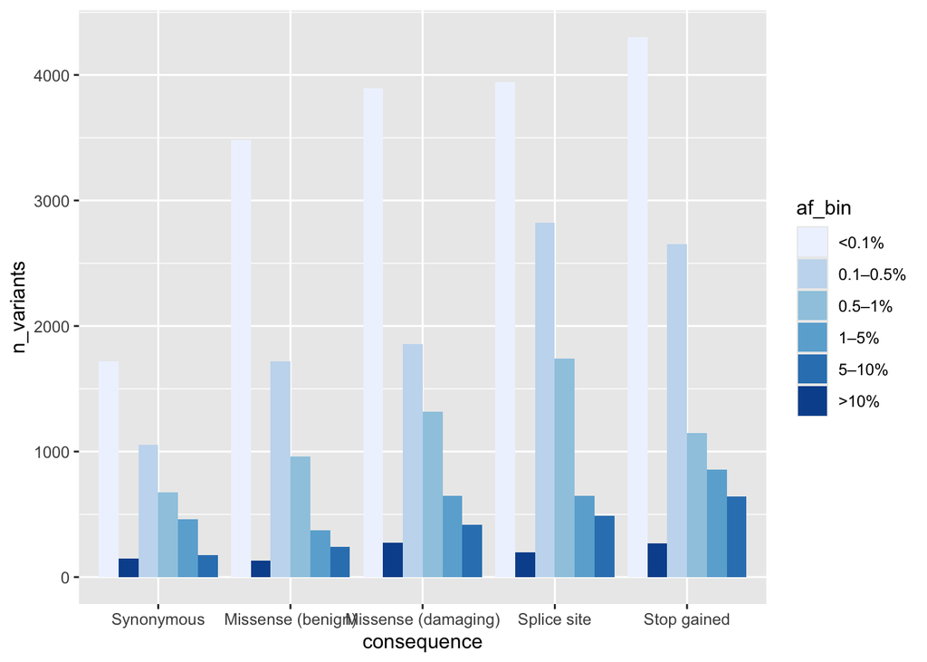

```r
# Add to this code

set.seed(1)

af_bins <- c(
  "<0.1%",
  "0.1–0.5%",
  "0.5–1%",
  "1–5%",
  "5–10%",
  ">10%"
)

severity <- c(
  "Synonymous",
  "Missense (benign)",
  "Missense (damaging)",
  "Splice site",
  "Stop gained"
)

df <- expand.grid(
  af_bin = factor(af_bins, levels = af_bins, ordered = TRUE),
  consequence = factor(severity, levels = severity, ordered = TRUE)
)

# rare variants are more likely to be severe
base <- exp(seq(log(5000), log(300), length.out = length(af_bins)))

df$n_variants <- round(
  base[as.integer(df$af_bin)] *
    rev(seq(1.0, 0.4, length.out = length(severity)))[as.integer(df$consequence)] *
    runif(nrow(df), 0.7, 1.3)
)
df$af_bin <- as.character(df$af_bin)

# Helper variable for you!
af_bins <- c(
  "<0.1%",
  "0.1–0.5%",
  "0.5–1%",
  "1–5%",
  "5–10%",
  ">10%"
)

# Plot
df %>%
  ggplot(.,
       aes(x = consequence,
           y = n_variants,
           fill = af_bin)) +
  geom_col(position="dodge") +

  scale_fill_brewer(palette="Blues",limits=af_bins)
```

Now the legend looks correct. But notice the bars are not in the desired order! At this point, it may be easier and simpler to just convert `af_bin` to a factor than to try to specify the “dodge” order of the bars. Here is the suggested fix:

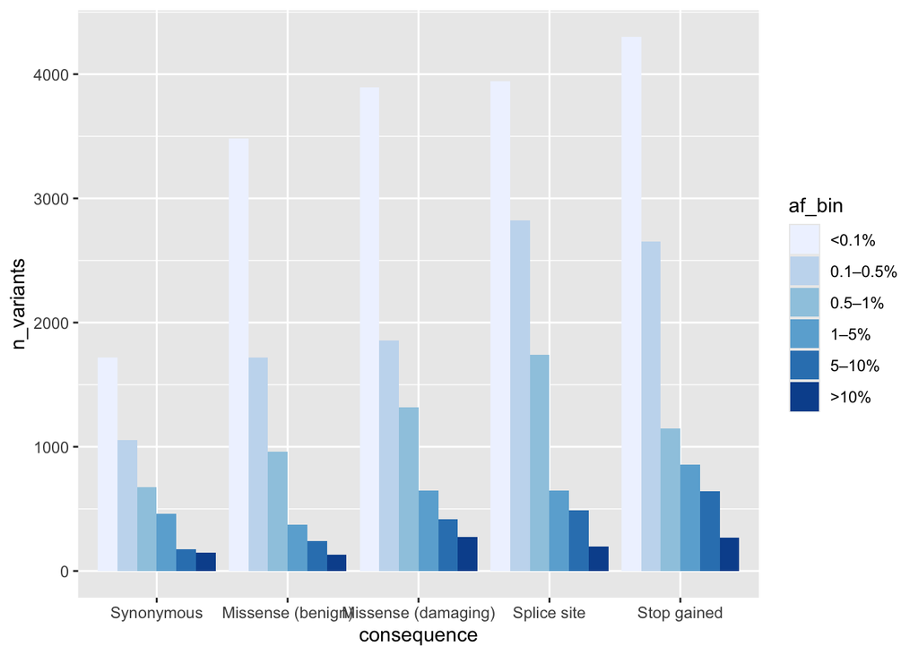

```r
# Add to this code
df %>%
  mutate(af_bin = factor(af_bin, levels = af_bins)) %>%
   ggplot(.,
       aes(x = consequence,
           y = n_variants,
           fill = af_bin)) +
  geom_col(position="dodge") +

  scale_fill_brewer(palette="Blues",limits=af_bins)
```

Now that we have the colors mapped in the right order and the bars in the right order, we notice that the lightest blue shade is a little too bright to see clearly. So let’s use `brewer.pal` to pick out a slightly better palette of blues.

We will use `brewer.pal` to pick out 9 shades from `"Blues"`:

```r
library("RColorBrewer")
brewer.pal(9, "Blues")
```

```
## [1] "#F7FBFF" "#DEEBF7" "#C6DBEF" "#9ECAE1" "#6BAED6" "#4292C6" "#2171B5"
## [8] "#08519C" "#08306B"
```

Then we will draw from the middle of these. We only need 6 shades:

```r
colors <- brewer.pal(9, "Blues")[4:9]
colors
```

```
## [1] "#9ECAE1" "#6BAED6" "#4292C6" "#2171B5" "#08519C" "#08306B"
```

Now modify the last plotting command above to include `scale_fill_manual()` instead of `scale_fill_brewer`, and supply `values=colors`. You also no longer need the `palette` option since `values` will override it.

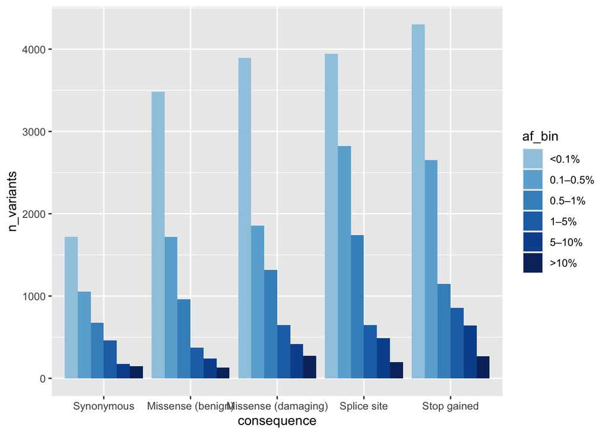

```r
# Add your code below
df %>%
  mutate(af_bin = factor(af_bin, levels = af_bins)) %>%
   ggplot(.,
       aes(x = consequence,
           y = n_variants,
           fill = af_bin)) +
  geom_col(position="dodge") +

  scale_fill_manual(limits=af_bins, values=colors)
```

Unfortunately, the built-in color palettes don’t have that many colors in them. We need to make a custom palette if we want, say, a sequential palette with 10 colors. Look what happens if we have a lot of bins - we run out of colors!

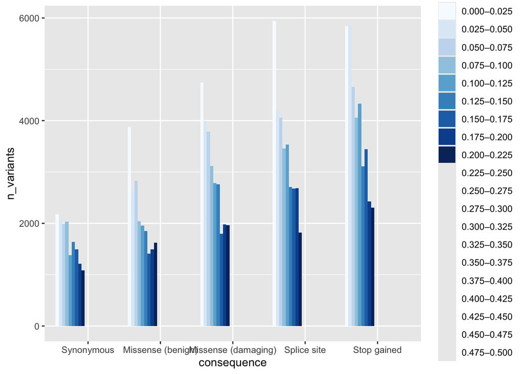

```r
# Many AF bins between 0 and 0.5
af_bins <- sprintf(
  "%.3f–%.3f",
  seq(0, 0.475, by = 0.025),
  seq(0.025, 0.5, by = 0.025)
)
severity <- c(
  "Synonymous",
  "Missense (benign)",
  "Missense (damaging)",
  "Splice site",
  "Stop gained"
)
set.seed(1)

df <- expand.grid(
  af_bin = af_bins,
  consequence = severity
)

# Make AF bins ordered *for plotting*
df$af_bin <- factor(df$af_bin, levels = af_bins)

# Baseline: rarer variants are more numerous
base <- exp(seq(log(6000), log(800), length.out = length(af_bins)))

df$n_variants <- round(
  base[as.integer(df$af_bin)] *
    rev(seq(1.0, 0.4, length.out = length(severity)))[
      match(df$consequence, severity)
    ] *
    runif(nrow(df), 0.8, 1.2)
)
library(ggplot2)

df %>%
  ggplot(aes(
    x = consequence,
    y = n_variants,
    fill = af_bin
  )) +
  geom_col(position = "dodge") +
  scale_fill_brewer(palette = "Blues")
```

The solution is to interpolate more colors with the `colorRampPalette` function, as many as we need. Use `cols <- colorRampPalette(RColorBrewer::brewer.pal(9, "Blues"))(n)`, where `n` is the number of colors you need. Modify the plotting code above.

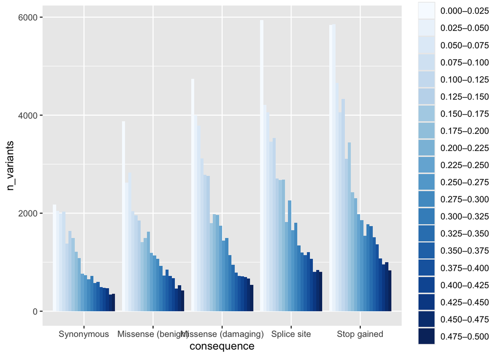

```r
# Your code here
cols <- colorRampPalette(
  RColorBrewer::brewer.pal(9, "Blues")
)(length(af_bins))

df %>%
  ggplot(aes(
    x = consequence,
    y = n_variants,
    fill = af_bin
  )) +
  geom_col(position = "dodge") +
  scale_fill_manual(
    values = cols,
    limits = af_bins
  )
```

Note that you can pick any two colors along which to create a gradient:

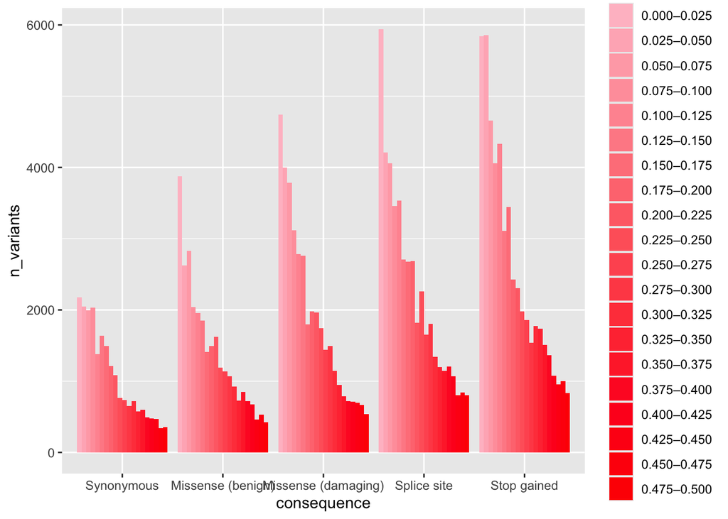

```r
cols <- colorRampPalette(c("pink", "red"))(length(af_bins))
df %>%
  ggplot(aes(
    x = consequence,
    y = n_variants,
    fill = af_bin
  )) +
  geom_col(position = "dodge") +
  scale_fill_manual(
    values = cols,
    limits = af_bins
  )
```

# 5. Bad defaults

# 6. How to lie

# 7. Show and tell

Find a bad, preferably funny graph and share it with the class.

Here’s one that I like:

https://i.redd.it/eyl7ae9vb3n41.png